# Customer Data Analysis for Business Insights

## Python Mini Project

**Name:** Tanmay Mandal, **Course:** Python **Date:** 22/02/2026

# 1. Introduction

This project analyzes customer transaction data to understand purchasing behavior, identify high-value customers, and perform RFM-based segmentation to support business decision-making.

# 2. Business Objective Section

The objective of this analysis is to:

- Understand customer purchasing patterns
- Identify high-value and at-risk customers
- Apply RFM analysis for segmentation
- Provide strategic business recommendations

# 3. Data Description

The project uses two datasets:

## Customer Transactions Data

```python
import os
os.getcwd()
```

```
'C:\\Users\\VORTEX\\OneDrive\\Desktop\\Python Vortex\\Python Mini Project'
```

```python
os.listdir()
```

```
['.ipynb_checkpoints',
 'Customer_Data_Analysis(Final).ipynb',
 'Customer_Master_Data.csv',
 'Customer_Master_Data.xlsx',
 'Customer_Transactions.csv',
 'Final_RFM_Table.csv',
 'Final_Segmented_Customers.csv',
 'proj.ipynb',
 'project02_Customer_Data_Analysis.ipynb',
 'Rules',
 'Untitled.ipynb']
```

```python
# Importing Important libraries
import pandas as pd
import numpy as np
import matplotlib.pyplot as plt
import seaborn as sns
```

```python
# Loading Datasets
customers = pd.read_csv("Customer_Master_Data.csv")
transactions = pd.read_csv("Customer_Transactions.csv")

print("Loaded Successfully")
```

```
Loaded Successfully
```

```python
customers["CustomerID"] = customers["CustomerID"].astype("category")
transactions["CustomerID"] = transactions["CustomerID"].astype("category")
```

```python
transactions.info(memory_usage="deep")
customers.info(memory_usage="deep")
```

```
<class 'pandas.core.frame.DataFrame'>
RangeIndex: 23050 entries, 0 to 23049
Data columns (total 3 columns):
 #   Column             Non-Null Count  Dtype
---  ------             --------------  -----
 0   CustomerID         23050 non-null  category
 1   TransactionDate    23050 non-null  object
 2   TransactionAmount  23050 non-null  float64
dtypes: category(1), float64(1), object(1)
memory usage: 1.5 MB
<class 'pandas.core.frame.DataFrame'>
RangeIndex: 1000 entries, 0 to 999
Data columns (total 9 columns):
 #   Column         Non-Null Count  Dtype
---  ------         --------------  -----
 0   CustomerID     1000 non-null   category
 1   Name           1000 non-null   object
 2   Email          1000 non-null   object
 3   Gender         1000 non-null   object
 4   Age            1000 non-null   int64
 5   City           1000 non-null   object
 6   MaritalStatus  1000 non-null   object
 7   NumChildren    1000 non-null   int64
 8   JoinDate       1000 non-null   object
dtypes: category(1), int64(2), object(6)
memory usage: 456.9 KB
```

```python
if "TransactionType" in transactions.columns:
    transactions["TransactionType"] = transactions["TransactionType"].astype("category")
```

```python
transactions["TransactionAmount"] = pd.to_numeric(
    transactions["TransactionAmount"],
    downcast="float"
)
```

```python
transactions.groupby(
    "CustomerID",
    sort=False,
    observed=True
)["TransactionAmount"].sum()
```

```
CustomerID
CUST10771    26455.820312
CUST10100    22368.019531
CUST10031    25724.970703
CUST10987    25293.300781
CUST10831    36714.390625
                 ...
CUST10649    33119.410156
CUST10597    19349.460938
CUST10588    17384.759766
CUST10729     5052.689941
CUST10548    19975.699219
Name: TransactionAmount, Length: 1000, dtype: float32
```

```python
customers.shape
```

```
(1000, 9)
```

```python
customers.head()
```

|  | CustomerID | Name | Email | Gender | Age | City | MaritalStatus | NumChildren | JoinDate |
| --- | --- | --- | --- | --- | --- | --- | --- | --- | --- |
| 0 | CUST10000 | Onkar Bhargava | pkeer@yahoo.com | Male | 54 | Delhi | Divorced | 0 | 2021-02-22 |
| 1 | CUST10001 | Divit Kohli | mkalita@sarin.com | Female | 48 | Kolkata | Married | 0 | 2023-12-06 |
| 2 | CUST10002 | Kiara Behl | apteanay@hotmail.com | Male | 75 | Kolkata | Widowed | 2 | 2023-08-23 |
| 3 | CUST10003 | Vaibhav Sankar | bseshadri@choudhry.info | Male | 62 | Pune | Divorced | 2 | 2022-11-17 |
| 4 | CUST10004 | Shray D’Alia | bdhillon@toor-mall.com | Male | 55 | Delhi | Divorced | 0 | 2022-12-04 |

```python
customers.describe()
```

|  | Age | NumChildren |
| --- | --- | --- |
| count | 1000.000000 | 1000.000000 |
| mean | 46.471000 | 1.311000 |
| std | 16.582525 | 1.190671 |
| min | 18.000000 | 0.000000 |
| 25% | 32.000000 | 0.000000 |
| 50% | 46.000000 | 1.000000 |
| 75% | 60.000000 | 2.000000 |
| max | 75.000000 | 4.000000 |

```python
transactions.shape
```

```
(23050, 3)
```

```python
transactions.head()
```

|  | CustomerID | TransactionDate | TransactionAmount |
| --- | --- | --- | --- |
| 0 | CUST10771 | 7/31/23 | 2383.070068 |
| 1 | CUST10100 | 3/10/24 | 497.540009 |
| 2 | CUST10031 | 2/17/25 | 536.780029 |
| 3 | CUST10987 | 7/17/23 | 314.890015 |
| 4 | CUST10831 | 12/15/24 | 2543.189941 |

```python
transactions.describe()
```

|  | TransactionAmount |
| --- | --- |
| count | 23050.000000 |
| mean | 1000.138855 |
| std | 703.357483 |
| min | 3.870000 |
| 25% | 482.107506 |
| 50% | 844.755005 |
| 75% | 1346.795044 |
| max | 6890.189941 |

### Interpretation

The summary statistics provide insights into customer age distribution and transaction behavior.

The transaction amount shows variability, indicating the presence of both low-value and high-value purchases. This suggests customer spending behavior differs significantly across segments.

# 4. Data Cleaning & Preprocessing

In this section, I have checked for missing values, converted date columns, and prepared the dataset for analysis.

```python
# Checking for Missing Values
customers.isnull().sum()
```

```
CustomerID       0
Name             0
Email            0
Gender           0
Age              0
City             0
MaritalStatus    0
NumChildren      0
JoinDate         0
dtype: int64
```

```python
transactions.isnull().sum()
```

```
CustomerID           0
TransactionDate      0
TransactionAmount    0
dtype: int64
```

```python
import warnings
warnings.filterwarnings("ignore", category=UserWarning)
```

```python
# Converting Date Columns to Datetime
customers['JoinDate'] = pd.to_datetime(customers['JoinDate'])
transactions['TransactionDate'] = pd.to_datetime(transactions['TransactionDate'])
```

```python
customers.info()
transactions.info()
```

```
<class 'pandas.core.frame.DataFrame'>
RangeIndex: 1000 entries, 0 to 999
Data columns (total 9 columns):
 #   Column         Non-Null Count  Dtype
---  ------         --------------  -----
 0   CustomerID     1000 non-null   category
 1   Name           1000 non-null   object
 2   Email          1000 non-null   object
 3   Gender         1000 non-null   object
 4   Age            1000 non-null   int64
 5   City           1000 non-null   object
 6   MaritalStatus  1000 non-null   object
 7   NumChildren    1000 non-null   int64
 8   JoinDate       1000 non-null   datetime64[ns]
dtypes: category(1), datetime64[ns](1), int64(2), object(5)
memory usage: 104.7+ KB
<class 'pandas.core.frame.DataFrame'>
RangeIndex: 23050 entries, 0 to 23049
Data columns (total 3 columns):
 #   Column             Non-Null Count  Dtype
---  ------             --------------  -----
 0   CustomerID         23050 non-null  category
 1   TransactionDate    23050 non-null  datetime64[ns]
 2   TransactionAmount  23050 non-null  float32
dtypes: category(1), datetime64[ns](1), float32(1)
memory usage: 355.4 KB
```

```python
# Checking for Duplicate Customers
customers.duplicated(subset='CustomerID').sum()
```

```
np.int64(0)
```

```python
# Validate CustomerIDs in Transactions
invalid_ids = transactions[~transactions['CustomerID'].isin(customers['CustomerID'])]
invalid_ids.shape
```

```
(0, 3)
```

```python
# Removing Negative or Zero Transaction Amounts
transactions[transactions['TransactionAmount'] <= 0].shape
```

```
(0, 3)
```

```python
# Detecting Outliers Using the IQR Method
# for extreme value
Q1 = transactions['TransactionAmount'].quantile(0.25)
Q3 = transactions['TransactionAmount'].quantile(0.75)

IQR = Q3 - Q1

lower_bound = Q1 - 1.5 * IQR
upper_bound = Q3 + 1.5 * IQR

lower_bound, upper_bound
```

```
(np.float64(-814.9238014221191), np.float64(2643.8263511657715))
```

```python
# for outliners
outliers = transactions[
    (transactions['TransactionAmount'] < lower_bound) |
    (transactions['TransactionAmount'] > upper_bound)
]

outliers.shape
```

```
(736, 3)
```

```python
# Standardize Text Columns
customers['Gender'] = customers['Gender'].str.strip().str.title()
customers['City'] = customers['City'].str.strip().str.title()
customers['MaritalStatus'] = customers['MaritalStatus'].str.strip().str.title()
```

```python
customers['Gender'].unique()
customers['MaritalStatus'].unique()
```

```
array(['Divorced', 'Married', 'Widowed', 'Single'], dtype=object)
```

### Interpretation

No duplicate records were found, ensuring data reliability and preventing inflated revenue calculations.

# 5. Exploratory Data Analysis (EDA)

This section analyzes transaction patterns, revenue trends, and customer distribution.

### Customer Master Dataset

```python
customers['CustomerID'].nunique() # Total Unique Customers
```

```
1000
```

```python
customers['Gender'].value_counts() #Gender Distribution
```

```
Gender
Female           340
Male             332
Not Disclosed    328
Name: count, dtype: int64
```

```python
(customers['Gender'].value_counts(normalize=True) * 100).round(2)
```

```
Gender
Female           34.0
Male             33.2
Not Disclosed    32.8
Name: proportion, dtype: float64
```

```python
customers['Age'].mean()
```

```
np.float64(46.471)
```

```python
# Top 5 Cities by Customer Count
customers['City'].value_counts().head(5)
```

```
City
Lucknow      110
Jaipur       109
Hyderabad    104
Ahmedabad    102
Bangalore    102
Name: count, dtype: int64
```

```python
# Married vs Single Percentage
customers['MaritalStatus'].value_counts(normalize=True) * 100
```

```
MaritalStatus
Widowed     28.0
Divorced    25.0
Single      24.6
Married     22.4
Name: proportion, dtype: float64
```

```python
# Creating Age Groups
bins = [18, 25, 35, 45, 55, 65, 100]
labels = ['18-25', '26-35', '36-45', '46-55', '56-65', '65+']

customers['AgeGroup'] = pd.cut(customers['Age'], bins=bins, labels=labels)

customers['AgeGroup'].value_counts()
```

```
AgeGroup
36-45    190
26-35    182
65+      180
46-55    175
56-65    149
18-25    112
Name: count, dtype: int64
```

### Transaction Dataset

```python
#  Total Transactions
transactions.shape[0]
```

```
23050
```

```python
#  Total Revenue
transactions['TransactionAmount'].sum()
```

```
np.float32(2.30532e+07)
```

```python
#  Average Transaction Amount
transactions['TransactionAmount'].mean()
```

```
np.float32(1000.13885)
```

```python
#  Highest & Lowest Transactions
transactions['TransactionAmount'].max()
```

```
6890.18994140625
```

```python
transactions['TransactionAmount'].min()
```

```
3.869999885559082
```

```python
#  Monthly Revenue Trend
transactions['YearMonth'] = transactions['TransactionDate'].dt.to_period('M')

monthly_revenue = transactions.groupby('YearMonth')['TransactionAmount'].sum()

monthly_revenue
```

```
YearMonth
2020-08      4920.700195
2020-09      8087.860352
2020-10     14035.639648
2020-11     26427.519531
2020-12     44923.808594
2021-01     46313.328125
2021-02     56751.058594
2021-03     73427.828125
2021-04     84110.148438
2021-05     83429.023438
2021-06     97844.992188
2021-07    106881.601562
2021-08    118871.710938
2021-09    118180.617188
2021-10    146381.546875
2021-11    131805.343750
2021-12    155506.953125
2022-01    174315.593750
2022-02    167072.437500
2022-03    223836.843750
2022-04    236575.468750
2022-05    237187.921875
2022-06    234176.703125
2022-07    251243.125000
2022-08    245218.093750
2022-09    269509.718750
2022-10    281834.593750
2022-11    291384.000000
2022-12    312764.312500
2023-01    346707.656250
2023-02    318612.156250
2023-03    376909.625000
2023-04    382688.937500
2023-05    412299.937500
2023-06    395256.812500
2023-07    419527.656250
2023-08    423156.187500
2023-09    549953.750000
2023-10    492321.968750
2023-11    516104.875000
2023-12    556071.250000
2024-01    628087.812500
2024-02    562946.500000
2024-03    598707.375000
2024-04    619173.062500
2024-05    746989.750000
2024-06    727259.937500
2024-07    782661.250000
2024-08    795313.000000
2024-09    737544.500000
2024-10    777659.687500
2024-11    720391.375000
2024-12    741476.437500
2025-01    798789.125000
2025-02    693491.875000
2025-03    752082.062500
2025-04    747412.187500
2025-05    770017.375000
2025-06    721939.687500
2025-07    698627.312500
Freq: M, Name: TransactionAmount, dtype: float32
```

```python
#  Top 10 Revenue-Generating Days
daily_revenue = transactions.groupby('TransactionDate')['TransactionAmount'].sum()

daily_revenue.sort_values(ascending=False).head(10)
```

```
TransactionDate
2024-08-30    50618.019531
2024-08-11    47048.371094
2024-10-31    44940.781250
2024-10-26    44171.261719
2024-09-01    42801.308594
2024-05-25    42017.839844
2024-11-06    41771.019531
2024-06-12    41352.539062
2024-01-06    39692.089844
2024-05-15    38925.570312
Name: TransactionAmount, dtype: float32
```

### Merging Customers & Transactions

```python
merged_data = pd.merge(
    customers,
    transactions,
    on='CustomerID',
    how='left'
)

merged_data.head()
```

|  | CustomerID | Name | Email | Gender | Age | City | MaritalStatus | NumChildren | JoinDate | AgeGroup | TransactionDate | TransactionAmount | YearMonth |
| --- | --- | --- | --- | --- | --- | --- | --- | --- | --- | --- | --- | --- | --- |
| 0 | CUST10000 | Onkar Bhargava | pkeer@yahoo.com | Male | 54 | Delhi | Divorced | 0 | 2021-02-22 | 46-55 | 2022-10-03 | 961.520020 | 2022-10 |
| 1 | CUST10000 | Onkar Bhargava | pkeer@yahoo.com | Male | 54 | Delhi | Divorced | 0 | 2021-02-22 | 46-55 | 2024-05-31 | 92.160004 | 2024-05 |
| 2 | CUST10000 | Onkar Bhargava | pkeer@yahoo.com | Male | 54 | Delhi | Divorced | 0 | 2021-02-22 | 46-55 | 2024-05-31 | 1153.739990 | 2024-05 |
| 3 | CUST10000 | Onkar Bhargava | pkeer@yahoo.com | Male | 54 | Delhi | Divorced | 0 | 2021-02-22 | 46-55 | 2023-01-31 | 1217.040039 | 2023-01 |
| 4 | CUST10000 | Onkar Bhargava | pkeer@yahoo.com | Male | 54 | Delhi | Divorced | 0 | 2021-02-22 | 46-55 | 2022-06-12 | 912.080017 | 2022-06 |

```python
merged_data.shape
```

```
(23050, 13)
```

```python
merged_data['TransactionAmount'].isnull().sum()
```

```
np.int64(0)
```

#### Total Spending per Customer

```python
total_spending = merged_data.groupby('CustomerID', observed=True)['TransactionAmount'].sum()

total_spending.head()
```

```
CustomerID
CUST10000    21265.490234
CUST10001    28654.308594
CUST10002    23884.029297
CUST10003    24206.029297
CUST10004    25565.300781
Name: TransactionAmount, dtype: float32
```

```python
total_spending = (
    merged_data
    .groupby('CustomerID', observed=True)['TransactionAmount']
    .sum()
)
```

```python
total_spending.describe()
```

```
count     1000.000000
mean     23053.199219
std       5622.441895
min       5052.689941
25%      18965.462891
50%      22969.820312
75%      26827.391602
max      44784.992188
Name: TransactionAmount, dtype: float64
```

#### Total Transactions per Customer

```python
total_transactions = merged_data.groupby('CustomerID', observed=True)['TransactionAmount'].count()

total_transactions.head()
```

```
CustomerID
CUST10000    23
CUST10001    30
CUST10002    24
CUST10003    25
CUST10004    19
Name: TransactionAmount, dtype: int64
```

```python
total_transactions = merged_data.groupby('CustomerID', observed=True)['TransactionAmount'].count()

total_transactions.head()
```

```
CustomerID
CUST10000    23
CUST10001    30
CUST10002    24
CUST10003    25
CUST10004    19
Name: TransactionAmount, dtype: int64
```

```python
total_transactions.mean()
```

```
np.float64(23.05)
```

#### Average Spending per Customer

```python
avg_spending = total_spending / total_transactions

avg_spending.head()
```

```
CustomerID
CUST10000     924.586532
CUST10001     955.143620
CUST10002     995.167887
CUST10003     968.241172
CUST10004    1345.542146
Name: TransactionAmount, dtype: float64
```

```python
avg_spending.describe()
```

```
count    1000.000000
mean     1002.637318
std       146.092813
min       625.343825
25%       901.710593
50%       995.191247
75%      1093.642017
max      1658.542969
Name: TransactionAmount, dtype: float64
```

# 6. RFM Analysis

RFM (Recency, Frequency, Monetary) analysis is used to evaluate customer value and segment customers based on purchasing behavior.

```python
# Defining Reference Date
merged_data['TransactionDate'] = pd.to_datetime(merged_data['TransactionDate'])
```

```python
reference_date = merged_data['TransactionDate'].max() + pd.Timedelta(days=1)
reference_date
```

```
Timestamp('2025-07-30 00:00:00')
```

```python
customers['JoinDate'] = pd.to_datetime(customers['JoinDate'])
```

#### Customer Lifetime (Days Since Join)

```python
customers['CustomerLifetimeDays'] = (
    reference_date - customers['JoinDate']
).dt.days

customers[['CustomerID', 'JoinDate', 'CustomerLifetimeDays']].head()
```

|  | CustomerID | JoinDate | CustomerLifetimeDays |
| --- | --- | --- | --- |
| 0 | CUST10000 | 2021-02-22 | 1619 |
| 1 | CUST10001 | 2023-12-06 | 602 |
| 2 | CUST10002 | 2023-08-23 | 707 |
| 3 | CUST10003 | 2022-11-17 | 986 |
| 4 | CUST10004 | 2022-12-04 | 969 |

```python
customers['CustomerLifetimeDays'].describe()
```

```
count    1000.000000
mean     1101.933000
std       429.190903
min       367.000000
25%       724.500000
50%      1115.500000
75%      1478.500000
max      1827.000000
Name: CustomerLifetimeDays, dtype: float64
```

#### Calculating Recency(R)

```python
recency = merged_data.groupby('CustomerID', observed=True)['TransactionDate'].max()

recency = (reference_date - recency).dt.days

recency.head()
```

```
CustomerID
CUST10000    13
CUST10001    35
CUST10002    18
CUST10003    81
CUST10004     8
Name: TransactionDate, dtype: int64
```

#### Calculating Frequency(F)

```python
frequency = merged_data.groupby('CustomerID', observed=True)['TransactionAmount'].count()

frequency.head()
```

```
CustomerID
CUST10000    23
CUST10001    30
CUST10002    24
CUST10003    25
CUST10004    19
Name: TransactionAmount, dtype: int64
```

#### Calculating Monetary(M)

```python
monetary = merged_data.groupby('CustomerID', observed=True)['TransactionAmount'].sum()

monetary.head()
```

```
CustomerID
CUST10000    21265.490234
CUST10001    28654.308594
CUST10002    23884.029297
CUST10003    24206.029297
CUST10004    25565.300781
Name: TransactionAmount, dtype: float32
```

```python
df_rfm = pd.DataFrame({
    'Recency': recency,
    'Frequency': frequency,
    'Monetary': monetary
})

df_rfm.head()
```

| CustomerID | Recency | Frequency | Monetary |
| --- | --- | --- | --- |
| CUST10000 | 13 | 23 | 21265.490234 |
| CUST10001 | 35 | 30 | 28654.308594 |
| CUST10002 | 18 | 24 | 23884.029297 |
| CUST10003 | 81 | 25 | 24206.029297 |
| CUST10004 | 8 | 19 | 25565.300781 |

#### RFM Scoring

```python
df_rfm['R_Score'] = pd.qcut(df_rfm['Recency'], 5, labels=[5,4,3,2,1])
df_rfm['F_Score'] = pd.qcut(df_rfm['Frequency'], 5, labels=[1,2,3,4,5])
df_rfm['M_Score'] = pd.qcut(df_rfm['Monetary'], 5, labels=[1,2,3,4,5])
```

#### Combined Score

```python
df_rfm['RFM_Score'] = (
    df_rfm['R_Score'].astype(str) +
    df_rfm['F_Score'].astype(str) +
    df_rfm['M_Score'].astype(str)
)

df_rfm.head()
```

| CustomerID | Recency | Frequency | Monetary | R_Score | F_Score | M_Score | RFM_Score |
| --- | --- | --- | --- | --- | --- | --- | --- |
| CUST10000 | 13 | 23 | 21265.490234 | 4 | 3 | 2 | 432 |
| CUST10001 | 35 | 30 | 28654.308594 | 3 | 5 | 5 | 355 |
| CUST10002 | 18 | 24 | 23884.029297 | 4 | 3 | 3 | 433 |
| CUST10003 | 81 | 25 | 24206.029297 | 1 | 4 | 3 | 143 |
| CUST10004 | 8 | 19 | 25565.300781 | 5 | 1 | 4 | 514 |

```python
df_rfm['RFM_Score'].value_counts().sort_values(ascending=False).head(10)
```

```
RFM_Score
311    37
555    35
111    34
411    33
511    28
355    26
211    26
544    22
455    22
122    21
Name: count, dtype: int64
```

```python
df_rfm['R_Score'] = df_rfm['R_Score'].astype(int)
df_rfm['F_Score'] = df_rfm['F_Score'].astype(int)
df_rfm['M_Score'] = df_rfm['M_Score'].astype(int)
```

### RFM analysis evaluates customer value using three dimensions:

- Recency: How recently a customer made a purchase
- Frequency: How often a customer purchases
- Monetary: How much money a customer spends

Customers with low recency, high frequency, and high monetary value are considered the most valuable.

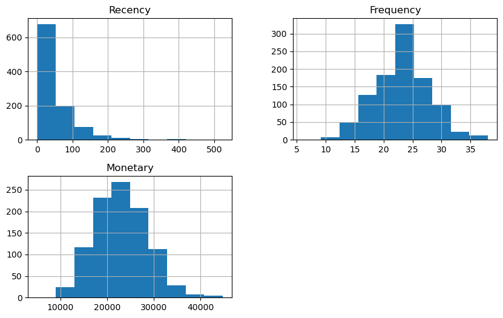

```python
df_rfm[['Recency','Frequency', 'Monetary']].hist(figsize=(10,6))
plt.show()
```

# 7. Customer Segmentation

Customers are grouped into segments such as Champions, Loyal Customers, At Risk, Hibernating, and Potential Loyalists based on RFM score combinations.

```python
# Creating Segment Column
def segment_customer(row):
    if row['R_Score'] == 5 and row['F_Score'] == 5 and row['M_Score'] == 5:
        return 'Champions'
    elif row['R_Score'] >= 4 and row['F_Score'] >= 4:
        return 'Loyal Customers'
    elif row['R_Score'] <= 2 and row['F_Score'] <= 2:
        return 'At Risk.'
    elif row['R_Score'] == 5:
        return 'Hibernating'
    else:
        return 'Potential Loyalist.'

df_rfm['Segment'] = df_rfm.apply(segment_customer, axis=1)

df_rfm.head()
```

| CustomerID | Recency | Frequency | Monetary | R_Score | F_Score | M_Score | RFM_Score | Segment |
| --- | --- | --- | --- | --- | --- | --- | --- | --- |
| CUST10000 | 13 | 23 | 21265.490234 | 4 | 3 | 2 | 432 | Potential Loyalist. |
| CUST10001 | 35 | 30 | 28654.308594 | 3 | 5 | 5 | 355 | Potential Loyalist. |
| CUST10002 | 18 | 24 | 23884.029297 | 4 | 3 | 3 | 433 | Potential Loyalist. |
| CUST10003 | 81 | 25 | 24206.029297 | 1 | 4 | 3 | 143 | Potential Loyalist. |
| CUST10004 | 8 | 19 | 25565.300781 | 5 | 1 | 4 | 514 | Hibernating |

```python
df_rfm['Segment'].value_counts()
```

```
Segment
Potential Loyalist.    523
At Risk.               193
Hibernating            127
Loyal Customers        122
Champions               35
Name: count, dtype: int64
```

```python
# Revenue per Segment
segment_revenue = df_rfm.groupby('Segment')['Monetary'].sum()

segment_revenue.sort_values(ascending=False)
```

```
Segment
Potential Loyalist.    1.232387e+07
At Risk.               3.734111e+06
Loyal Customers        3.298518e+06
Hibernating            2.597312e+06
Champions              1.099394e+06
Name: Monetary, dtype: float32
```

```python
# Percentage Revenue Contribution
(segment_revenue / segment_revenue.sum() * 100).round(2)
```

```
Segment
At Risk.               16.200001
Champions               4.770000
Hibernating            11.270000
Loyal Customers        14.310000
Potential Loyalist.    53.459999
Name: Monetary, dtype: float32
```

```python
df_rfm[df_rfm['Segment'] == 'At Risk.'].head()
```

| CustomerID | Recency | Frequency | Monetary | R_Score | F_Score | M_Score | RFM_Score | Segment |
| --- | --- | --- | --- | --- | --- | --- | --- | --- |
| CUST10007 | 86 | 15 | 14957.060547 | 1 | 1 | 1 | 111 | At Risk. |
| CUST10018 | 72 | 19 | 20383.919922 | 2 | 1 | 2 | 212 | At Risk. |
| CUST10022 | 60 | 15 | 21368.650391 | 2 | 1 | 3 | 213 | At Risk. |
| CUST10030 | 72 | 17 | 15128.229492 | 2 | 1 | 1 | 211 | At Risk. |
| CUST10034 | 153 | 21 | 30387.640625 | 1 | 2 | 5 | 125 | At Risk. |

```python
df_rfm[df_rfm['Segment'] == 'At Risk.'].shape
```

```
(193, 8)
```

```python
at_risk_revenue = df_rfm[df_rfm['Segment']=='At Risk.']['Monetary'].sum()
total_revenue = df_rfm['Monetary'].sum()
```

```python
risk_percentage = (at_risk_revenue / total_revenue) * 100
risk_percentage
```

```
np.float32(16.1978)
```

### Revenue Risk Analysis

Approximately 16.19% of total revenue is generated by customers classified as At Risk.

This represents a significant revenue exposure. If these customers churn, the business could lose nearly one-sixth of its revenue.

Immediate re-engagement strategies such as personalized discounts, loyalty incentives, and targeted email campaigns should be implemented to retain this segment.

```python
# Identifying Top Revenue Segment
segment_revenue.sort_values(ascending=False)
```

```
Segment
Potential Loyalist.    1.232387e+07
At Risk.               3.734111e+06
Loyal Customers        3.298518e+06
Hibernating            2.597312e+06
Champions              1.099394e+06
Name: Monetary, dtype: float32
```

### Interpretation

Retaining these customers is critical for long-term profitability.

# 8. Data Visualization

### Gender Distribution (Pie Chart)

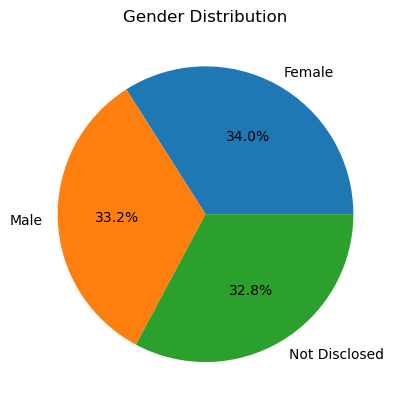

```python
import matplotlib.pyplot as plt
# Gender Distribution (Pie Chart)
gender_counts = customers['Gender'].value_counts()

plt.figure()
plt.pie(gender_counts, labels=gender_counts.index, autopct='%1.1f%%')
plt.title('Gender Distribution')
plt.show()
```

### Age Distribution (Histogram)

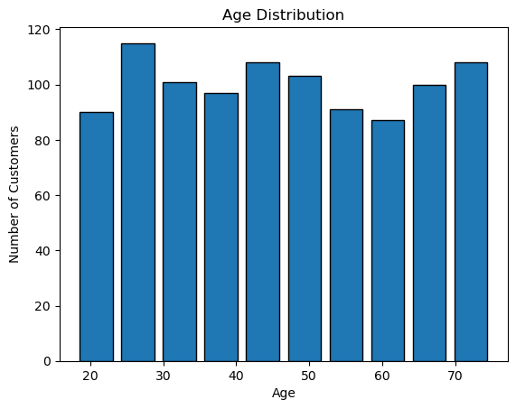

```python
plt.figure()
plt.hist(customers['Age'], bins=10, edgecolor='black', rwidth=0.8)
plt.title('Age Distribution')
plt.xlabel('Age')
plt.ylabel('Number of Customers')
plt.show()
```

### City-wise Customer Count (Bar Chart)

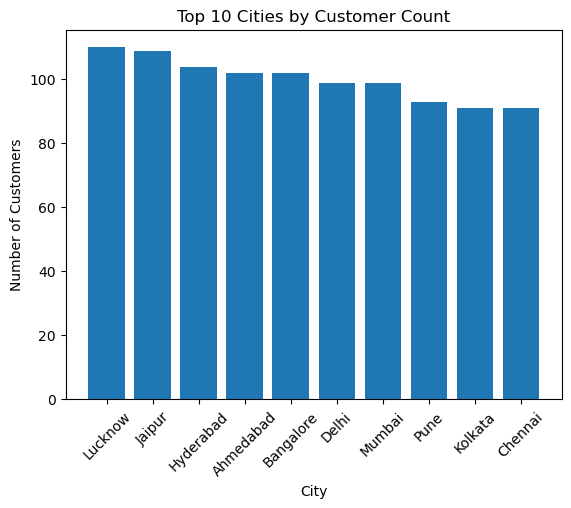

```python
city_counts = customers['City'].value_counts().head(10)

plt.figure()
plt.bar(city_counts.index, city_counts.values)
plt.title('Top 10 Cities by Customer Count')
plt.xticks(rotation=45)
plt.xlabel('City')
plt.ylabel('Number of Customers')
plt.show()
```

```python
# checking- date is datetime
merged_data['TransactionDate'] = pd.to_datetime(merged_data['TransactionDate'])

# Creating YearMonth column
merged_data['YearMonth'] = merged_data['TransactionDate'].dt.to_period('M')

# Calculate monthly revenue
monthly_revenue = merged_data.groupby('YearMonth')['TransactionAmount'].sum()

monthly_revenue.head()
```

```
YearMonth
2020-08     4920.700195
2020-09     8087.859863
2020-10    14035.639648
2020-11    26427.519531
2020-12    44923.808594
Freq: M, Name: TransactionAmount, dtype: float32
```

### Monthly Revenue Trend (Line Chart)

```python
monthly_revenue.index = monthly_revenue.index.to_timestamp()
```

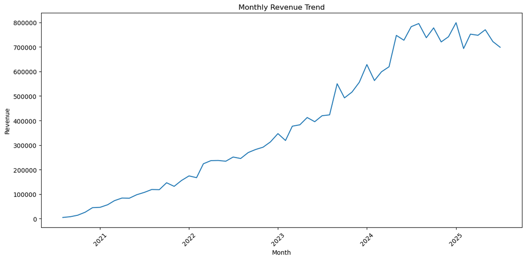

```python
plt.figure(figsize=(12,6))

plt.plot(monthly_revenue.index, monthly_revenue.values)

plt.title('Monthly Revenue Trend')
plt.xlabel('Month')
plt.ylabel('Revenue')

plt.xticks(rotation=45)
plt.tight_layout()
plt.show()
```

### Interpretation

Seasonal peaks may indicate promotional campaigns or festive demand.

### Segment-wise Customer Count (Bar Chart)

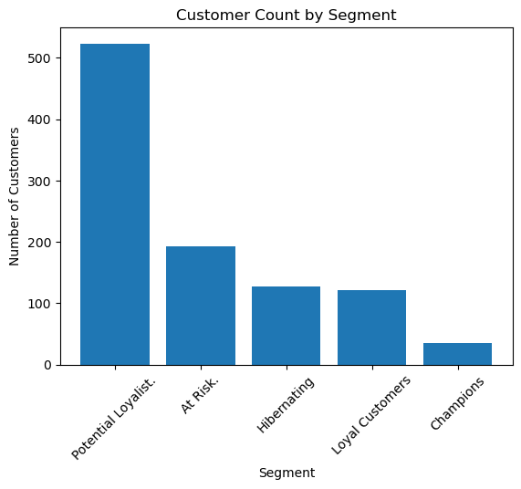

```python
segment_counts = df_rfm['Segment'].value_counts()

plt.figure()
plt.bar(segment_counts.index, segment_counts.values)
plt.xticks(rotation=45)
plt.title('Customer Count by Segment')
plt.xlabel('Segment')
plt.ylabel('Number of Customers')
plt.show()
```

### Interpretation

The distribution of segments shows that while a portion of customers are highly engaged, a considerable number fall into At Risk and Hibernating categories.

This indicates an opportunity for reactivation campaigns.

### Segment-wise Revenue

```python
segment_revenue = df_rfm.groupby("Segment")["Monetary"].sum().sort_values(ascending=False)
segment_revenue
```

```
Segment
Potential Loyalist.    1.232387e+07
At Risk.               3.734111e+06
Loyal Customers        3.298518e+06
Hibernating            2.597312e+06
Champions              1.099394e+06
Name: Monetary, dtype: float32
```

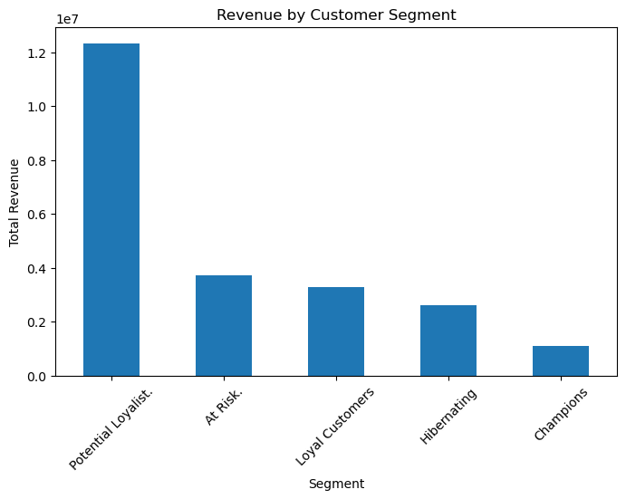

```python
import matplotlib.pyplot as plt

segment_revenue.plot(kind="bar", figsize=(8,5))
plt.title("Revenue by Customer Segment")
plt.xlabel("Segment")
plt.ylabel("Total Revenue")
plt.xticks(rotation=45)
plt.show()
```

### Scatter Plot: Recency vs Monetary

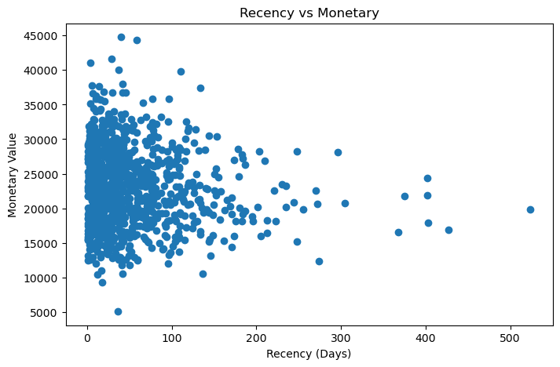

```python
plt.figure(figsize=(8,5))
plt.scatter(df_rfm["Recency"], df_rfm["Monetary"])
plt.title("Recency vs Monetary")
plt.xlabel("Recency (Days)")
plt.ylabel("Monetary Value")
plt.show()
```

### Pareto Chart (Top 20% Customers Revenue Share)

```python
df_rfm_sorted = df_rfm.sort_values("Monetary", ascending=False)
```

```python
df_rfm_sorted = df_rfm.sort_values(by="Monetary", ascending=False)
df_rfm_sorted["CumulativeRevenue"] = df_rfm_sorted["Monetary"].cumsum()
df_rfm_sorted["CumulativePercent"] = (
    df_rfm_sorted["CumulativeRevenue"] / df_rfm_sorted["Monetary"].sum()
) * 100
```

```python
df_rfm_sorted["CumulativeRevenue"] = df_rfm_sorted["Monetary"].cumsum()
df_rfm_sorted["CumulativePercent"] = 100 * df_rfm_sorted["CumulativeRevenue"] / df_rfm_sorted["Monetary"].sum()
```

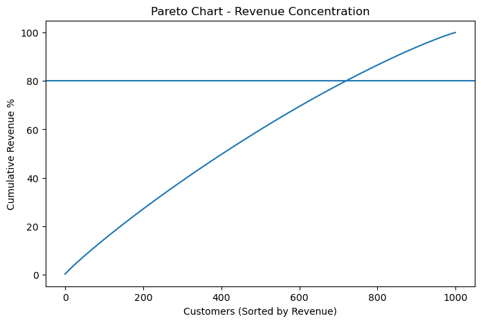

```python
import matplotlib.pyplot as plt
plt.figure(figsize=(8,5))
plt.plot(df_rfm_sorted["CumulativePercent"].values)
plt.axhline(80)
plt.title("Pareto Chart - Revenue Concentration")
plt.xlabel("Customers (Sorted by Revenue)")
plt.ylabel("Cumulative Revenue %")
plt.show()
```

### Heatmap of R vs F Scores

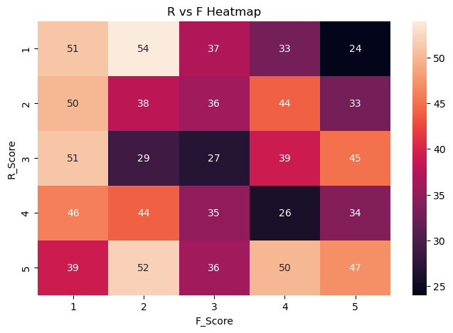

```python
import seaborn as sns
import matplotlib.pyplot as plt

df_rfm_pivot = df_rfm.pivot_table(
    index="R_Score",
    columns="F_Score",
    values="Monetary",
    aggfunc="count"
).fillna(0)

plt.figure(figsize=(8,5))
sns.heatmap(df_rfm_pivot, annot=True, fmt=".0f")
plt.title("R vs F Heatmap")
plt.show()
```

### Interpretation

This suggests that maintaining purchase frequency directly impacts revenue growth.

### Box plotting of Transaction Amount Distribution

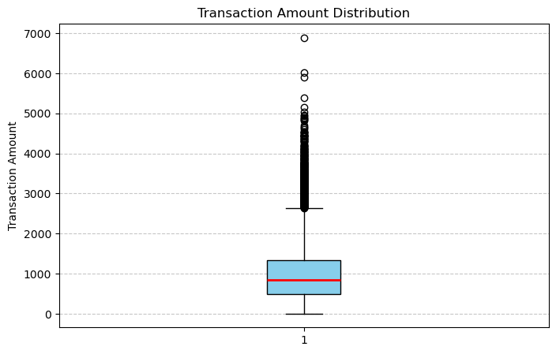

```python
plt.figure(figsize=(8,5))

plt.boxplot(
    transactions["TransactionAmount"],
    patch_artist=True,
    boxprops=dict(facecolor="skyblue", color="black"),
    medianprops=dict(color="red", linewidth=2),
    whiskerprops=dict(color="black"),
    capprops=dict(color="black")
)

plt.title("Transaction Amount Distribution")
plt.ylabel("Transaction Amount")
plt.grid(axis='y', linestyle='--', alpha=0.7)
plt.show()
```

### Interpretation

The presence of outliers suggests that a few customers make significantly larger purchases.

These customers represent premium buyers and should be targeted with personalized marketing.

# 9. Key Business Insights

This section summarizes major findings derived from the analysis.

```python
monthly_customers = transactions.groupby("YearMonth")["CustomerID"].nunique()

retention_rate = monthly_customers.pct_change().mean()

retention_rate
```

```
np.float64(0.10986147965482872)
```

### Repeat Purchase Rate

```python
customer_txn_count = transactions.groupby("CustomerID", observed=True).size()
```

```python
repeat_customers = (customer_txn_count > 1).sum()
total_customers = customer_txn_count.count()

repeat_purchase_rate = repeat_customers / total_customers
repeat_purchase_rate
```

```
np.float64(1.0)
```

```python
customer_txn_count.value_counts().head()
```

```
23    96
22    87
24    75
20    71
25    69
Name: count, dtype: int64
```

### Avgerage Gap b/w Purchases

```python
transactions = transactions.sort_values(["CustomerID", "TransactionDate"])

transactions["PreviousPurchase"] = transactions.groupby("CustomerID", observed=True)["TransactionDate"].shift(1)

transactions["GapDays"] = (transactions["TransactionDate"] - transactions["PreviousPurchase"]).dt.days

average_gap = transactions["GapDays"].mean()

average_gap
```

```
np.float64(45.529750566893426)
```

### Identifying Inactive Customers for 90+ Days

```python
reference_date = transactions["TransactionDate"].max() + pd.Timedelta(days=1)
```

```python
last_purchase = transactions.groupby("CustomerID", observed=True)["TransactionDate"].max()
```

```python
inactive_days = (reference_date - last_purchase).dt.days
```

```python
inactive_customers = inactive_days[inactive_days >= 90]

len(inactive_customers)
```

```
169
```

### Ranking Customers by Monetary Value

```python
df_rfm["MonetaryRank"] = df_rfm["Monetary"].rank(ascending=False)

df_rfm.sort_values("MonetaryRank").head(10)
```

| CustomerID | Recency | Frequency | Monetary | R_Score | F_Score | M_Score | RFM_Score | Segment | MonetaryRank |
| --- | --- | --- | --- | --- | --- | --- | --- | --- | --- |
| CUST10944 | 40 | 31 | 44784.992188 | 3 | 5 | 5 | 355 | Potential Loyalist. | 1.0 |
| CUST10510 | 59 | 30 | 44367.328125 | 2 | 5 | 5 | 255 | Potential Loyalist. | 2.0 |
| CUST10053 | 29 | 30 | 41674.558594 | 3 | 5 | 5 | 355 | Potential Loyalist. | 3.0 |
| CUST10776 | 4 | 33 | 41050.761719 | 5 | 5 | 5 | 555 | Champions | 4.0 |
| CUST10696 | 37 | 30 | 40035.480469 | 3 | 5 | 5 | 355 | Potential Loyalist. | 5.0 |
| CUST10671 | 111 | 34 | 39763.519531 | 1 | 5 | 5 | 155 | Potential Loyalist. | 6.0 |
| CUST10477 | 42 | 36 | 38015.781250 | 3 | 5 | 5 | 355 | Potential Loyalist. | 7.0 |
| CUST10196 | 6 | 35 | 37738.941406 | 5 | 5 | 5 | 555 | Champions | 8.0 |
| CUST10187 | 14 | 30 | 37627.781250 | 4 | 5 | 5 | 455 | Loyal Customers | 9.0 |
| CUST10413 | 134 | 36 | 37479.390625 | 1 | 5 | 5 | 155 | Potential Loyalist. | 10.0 |

### Identifying High-Value Customers in Each City

```python
merged = pd.merge(df_rfm, customers, on="CustomerID")
high_value_city = merged.sort_values("Monetary", ascending=False)\
                        .groupby("City")\
                        .head(3)

high_value_city[["CustomerID", "City", "Monetary"]]
```

|  | CustomerID | City | Monetary |
| --- | --- | --- | --- |
| 944 | CUST10944 | Ahmedabad | 44784.992188 |
| 510 | CUST10510 | Delhi | 44367.328125 |
| 53 | CUST10053 | Jaipur | 41674.558594 |
| 776 | CUST10776 | Lucknow | 41050.761719 |
| 696 | CUST10696 | Delhi | 40035.480469 |
| 671 | CUST10671 | Hyderabad | 39763.519531 |
| 477 | CUST10477 | Mumbai | 38015.781250 |
| 196 | CUST10196 | Chennai | 37738.941406 |
| 187 | CUST10187 | Kolkata | 37627.781250 |
| 413 | CUST10413 | Delhi | 37479.390625 |
| 179 | CUST10179 | Mumbai | 36781.371094 |
| 831 | CUST10831 | Jaipur | 36714.390625 |
| 876 | CUST10876 | Lucknow | 36661.468750 |
| 249 | CUST10249 | Ahmedabad | 36299.339844 |
| 752 | CUST10752 | Lucknow | 35848.371094 |
| 553 | CUST10553 | Bangalore | 35846.250000 |
| 312 | CUST10312 | Ahmedabad | 35451.320312 |
| 720 | CUST10720 | Pune | 35168.679688 |
| 182 | CUST10182 | Bangalore | 34487.058594 |
| 470 | CUST10470 | Bangalore | 34133.308594 |
| 148 | CUST10148 | Hyderabad | 33617.238281 |
| 517 | CUST10517 | Kolkata | 33278.660156 |
| 160 | CUST10160 | Pune | 33240.710938 |
| 560 | CUST10560 | Jaipur | 33199.468750 |
| 649 | CUST10649 | Mumbai | 33119.410156 |
| 617 | CUST10617 | Hyderabad | 32881.781250 |
| 290 | CUST10290 | Chennai | 32842.082031 |
| 854 | CUST10854 | Kolkata | 32764.660156 |
| 380 | CUST10380 | Pune | 32543.128906 |
| 352 | CUST10352 | Chennai | 32522.820312 |

### Spend Analysis b/w Married & Single Customers

```python
marital_spending = merged.groupby("MaritalStatus")["Monetary"].mean()
marital_spending
```

```
MaritalStatus
Divorced    23446.660156
Married     23373.568359
Single      22350.005859
Widowed     23063.406250
Name: Monetary, dtype: float32
```

```python
merged.groupby("MaritalStatus")["Monetary"].sum()
```

```
MaritalStatus
Divorced    5861665.0
Married     5235679.5
Single      5498101.5
Widowed     6457754.0
Name: Monetary, dtype: float32
```

### Revenue Growth (Month wise)

```python
monthly_revenue = transactions.groupby("YearMonth")["TransactionAmount"].sum()

monthly_growth = monthly_revenue.pct_change()

monthly_growth
```

```
YearMonth
2020-08         NaN
2020-09    0.643640
2020-10    0.735396
2020-11    0.882887
2020-12    0.699887
2021-01    0.030931
2021-02    0.225372
2021-03    0.293858
2021-04    0.145481
2021-05   -0.008098
2021-06    0.172793
2021-07    0.092356
2021-08    0.112181
2021-09   -0.005814
2021-10    0.238626
2021-11   -0.099577
2021-12    0.179823
2022-01    0.120950
2022-02   -0.041552
2022-03    0.339759
2022-04    0.056910
2022-05    0.002589
2022-06   -0.012695
2022-07    0.072878
2022-08   -0.023981
2022-09    0.099061
2022-10    0.045731
2022-11    0.033883
2022-12    0.073375
2023-01    0.108527
2023-02   -0.081035
2023-03    0.182973
2023-04    0.015333
2023-05    0.077376
2023-06   -0.041337
2023-07    0.061405
2023-08    0.008649
2023-09    0.299647
2023-10   -0.104794
2023-11    0.048308
2023-12    0.077438
2024-01    0.129510
2024-02   -0.103714
2024-03    0.063524
2024-04    0.034183
2024-05    0.206431
2024-06   -0.026412
2024-07    0.076178
2024-08    0.016165
2024-09   -0.072636
2024-10    0.054390
2024-11   -0.073642
2024-12    0.029269
2025-01    0.077295
2025-02   -0.131821
2025-03    0.084486
2025-04   -0.006209
2025-05    0.030245
2025-06   -0.062437
2025-07   -0.032291
Freq: M, Name: TransactionAmount, dtype: float32
```

### Identifying Peak Shopping Season

```python
monthly_revenue.sort_values(ascending=False)
```

```
YearMonth
2025-01    798789.125000
2024-08    795313.000000
2024-07    782661.250000
2024-10    777659.687500
2025-05    770017.375000
2025-03    752082.062500
2025-04    747412.187500
2024-05    746989.750000
2024-12    741476.437500
2024-09    737544.500000
2024-06    727259.937500
2025-06    721939.750000
2024-11    720391.375000
2025-07    698627.312500
2025-02    693491.875000
2024-01    628087.812500
2024-04    619173.062500
2024-03    598707.375000
2024-02    562946.500000
2023-12    556071.250000
2023-09    549953.750000
2023-11    516104.875000
2023-10    492321.968750
2023-08    423156.187500
2023-07    419527.656250
2023-05    412299.937500
2023-06    395256.812500
2023-04    382688.937500
2023-03    376909.625000
2023-01    346707.656250
2023-02    318612.156250
2022-12    312764.312500
2022-11    291384.000000
2022-10    281834.593750
2022-09    269509.718750
2022-07    251243.125000
2022-08    245218.093750
2022-05    237187.921875
2022-04    236575.468750
2022-06    234176.703125
2022-03    223836.843750
2022-01    174315.593750
2022-02    167072.437500
2021-12    155506.953125
2021-10    146381.546875
2021-11    131805.343750
2021-08    118871.710938
2021-09    118180.617188
2021-07    106881.601562
2021-06     97844.992188
2021-04     84110.148438
2021-05     83429.023438
2021-03     73427.828125
2021-02     56751.058594
2021-01     46313.332031
2020-12     44923.808594
2020-11     26427.519531
2020-10     14035.639648
2020-09      8087.859863
2020-08      4920.700195
Freq: M, Name: TransactionAmount, dtype: float32
```

### DASHBOARD SUMMARY TABLE

```python
summary = pd.DataFrame({
    "Total Customers": [transactions["CustomerID"].nunique()],
    "Total Revenue": [transactions["TransactionAmount"].sum()],
    "Avg Transaction": [transactions["TransactionAmount"].mean()],
    "Repeat Purchase Rate": [repeat_purchase_rate],
    "Avg Gap Days": [average_gap]
})

summary
```

|  | Total Customers | Total Revenue | Avg Transaction | Repeat Purchase Rate | Avg Gap Days |
| --- | --- | --- | --- | --- | --- |
| 0 | 1000 | 23053200.0 | 1000.138855 | 1.0 | 45.529751 |

#### Optimization

```python
optimized_rfm = transactions.groupby("CustomerID", observed=True).agg(
    Monetary=("TransactionAmount", "sum"),
    Frequency=("TransactionAmount", "count"),
    LastPurchase=("TransactionDate", "max")
)

optimized_rfm.head()
```

| CustomerID | Monetary | Frequency | LastPurchase |
| --- | --- | --- | --- |
| CUST10000 | 21265.490234 | 23 | 2025-07-17 |
| CUST10001 | 28654.310547 | 30 | 2025-06-25 |
| CUST10002 | 23884.031250 | 24 | 2025-07-12 |
| CUST10003 | 24206.031250 | 25 | 2025-05-10 |
| CUST10004 | 25565.300781 | 19 | 2025-07-22 |

```python
transactions = transactions.sort_values(
    by=["CustomerID", "TransactionDate"]
)

transactions["GapDays"] = (
    transactions["TransactionDate"] -
    transactions.groupby("CustomerID", observed=True)["TransactionDate"].shift(1)
).dt.days
```

```python
transactions[["CustomerID", "TransactionDate", "GapDays"]].head(15)
```

|  | CustomerID | TransactionDate | GapDays |
| --- | --- | --- | --- |
| 19951 | CUST10000 | 2021-05-02 | NaN |
| 11952 | CUST10000 | 2021-06-29 | 58.0 |
| 16322 | CUST10000 | 2022-04-14 | 289.0 |
| 5352 | CUST10000 | 2022-04-21 | 7.0 |
| 4308 | CUST10000 | 2022-06-12 | 52.0 |
| 10032 | CUST10000 | 2022-10-01 | 111.0 |
| 761 | CUST10000 | 2022-10-03 | 2.0 |
| 3847 | CUST10000 | 2023-01-31 | 120.0 |
| 14157 | CUST10000 | 2023-02-14 | 14.0 |
| 22088 | CUST10000 | 2023-03-31 | 45.0 |
| 11048 | CUST10000 | 2023-04-15 | 15.0 |
| 16889 | CUST10000 | 2023-05-21 | 36.0 |
| 18033 | CUST10000 | 2023-09-21 | 123.0 |
| 7460 | CUST10000 | 2024-02-04 | 136.0 |
| 11612 | CUST10000 | 2024-02-25 | 21.0 |

# 10. Business Recommendations

1. Focus retention efforts on Champions and Loyal Customers.
2. Launch reactivation campaigns for At Risk customers.
3. Provide loyalty benefits for high Monetary customers.
4. Optimize marketing spend in high-performing cities.
5. Introduce personalized promotions based on RFM score.

# 11. Conclusion

This project successfully applied RFM segmentation to identify customer value groups.

The analysis demonstrates that targeted retention and personalized marketing strategies can significantly increase revenue and customer lifetime value.

By focusing on high-value segments and re-engaging inactive customers, the business can improve profitability and long-term sustainability.

```python
df_rfm.to_csv("Final_RFM_Table.csv", index=False)
```

```python
merged.to_csv("Final_Segmented_Customers.csv", index=False)
```